# Data Science 3: Assignment 2

Benedek Pásztor

2019 04 06

## Deep neural nets with `keras`

The [homepage](https://keras.rstudio.com/) has great descrpitions, expamples and tutorials. Cheatsheet [here](https://www.rstudio.com/resources/cheatsheets/).

```r
# install.packages("keras")
library(keras)
# install_keras()
```

```r
library(keras)
library(here)
library(grid)
library(magick)  # not absolutely necessary
fashion_mnist <- dataset_fashion_mnist()
x_train <- fashion_mnist$train$x
y_train <- fashion_mnist$train$y
x_test <- fashion_mnist$test$x
y_test <- fashion_mnist$test$y
```

### a. Show some example images from the data.

[figure not shown]

```r
show_mnist_image <- function(x) {
  image(1:28, 1:28, t(x)[,nrow(x):1],col=gray((0:255)/255))
}

show_mnist_image(x_train[18, , ])
```

[figure not shown]

```r
show_mnist_image(x_train[27, , ])
```

[figure not shown]

```r
show_mnist_image(x_train[98, , ])
```

### b. Train a fully connected deep network to predict items.

##### - Normalize the data similarly to what we saw with MNIST.

```r
# reshape
x_train <- array_reshape(x_train, c(dim(x_train)[1], 784))
x_test <- array_reshape(x_test, c(dim(x_test)[1], 784))
# rescale
x_train <- x_train / 255
x_test <- x_test / 255

# one-hot encoding of the target variable
y_train <- to_categorical(y_train, 10)
y_test <- to_categorical(y_test, 10)
```

##### - Experiment with network architectures and settings (number of hidden layers, number of nodes, activation functions, dropout, etc.)

###### Model 1

```r
model <- keras_model_sequential()
model <- model %>%
  layer_dense(units = 128, activation = 'relu', input_shape = c(784)) %>%
  layer_dropout(rate = 0.3) %>%
  layer_dense(units = 10, activation = 'softmax')
```

```r
summary(model)
```

```
## ___________________________________________________________________________
## Layer (type)                     Output Shape                  Param #
## ===========================================================================
## dense_1 (Dense)                  (None, 128)                   100480
## ___________________________________________________________________________
## dropout_1 (Dropout)              (None, 128)                   0
## ___________________________________________________________________________
## dense_2 (Dense)                  (None, 10)                    1290
## ===========================================================================
## Total params: 101,770
## Trainable params: 101,770
## Non-trainable params: 0
## ___________________________________________________________________________
```

```r
model %>% compile(
  loss = 'categorical_crossentropy',
  optimizer = optimizer_rmsprop(),
  metrics = c('accuracy')
)
```

```r
history <- model %>% fit(x_train, y_train, epochs = 50, batch_size = 128, validation_split = 0.2)
```

```r
model %>% evaluate(x_test, y_test)
```

```
## $loss
## [1] 0.4202186
##
## $acc
## [1] 0.884
```

##### - Explain what you have tried, what worked and what did not. Present a final model.

##### - Make sure that you use enough epochs so that the validation error starts flattening out - provide a plot about the training history (plot(history))

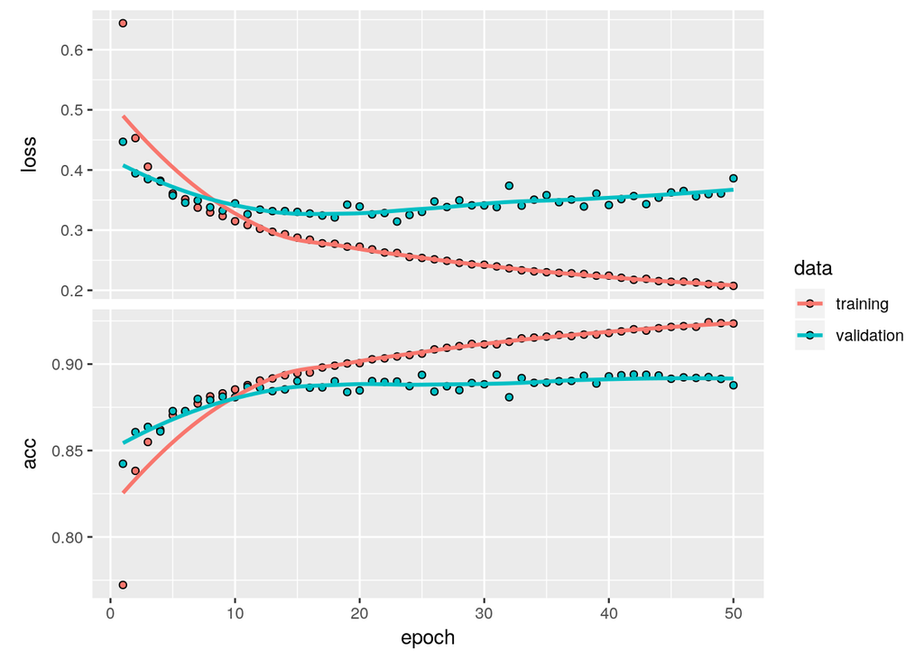

```r
plot(history)
```

###### Error check

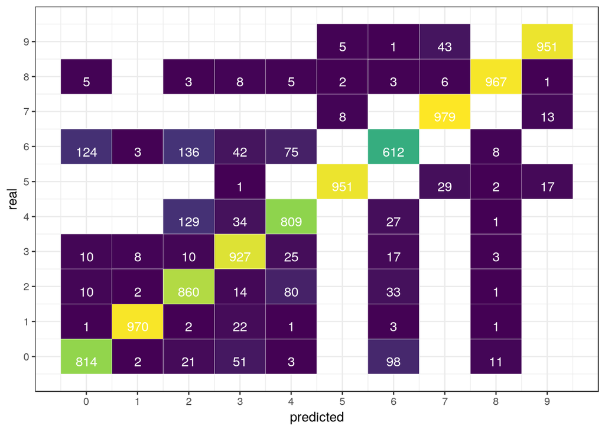

```r
predicted_classes_test <- model %>% predict_classes(x_test)
real_classes_test <- as.numeric(fashion_mnist$test$y)
library(data.table)
dt_pred_vs_real <- data.table(predicted = predicted_classes_test, real = real_classes_test)

library(ggplot2)
ggplot(dt_pred_vs_real[, .N, by = .(predicted, real)], aes(predicted, real)) +
  geom_tile(aes(fill = N), colour = "white") +
  scale_x_continuous(breaks = 0:9) +
  scale_y_continuous(breaks = 0:9) +
  geom_text(aes(label = sprintf("%1.0f", N)), vjust = 1, color = "white") +
  scale_fill_viridis_c() +
  theme_bw() + theme(legend.position = "none")
```

```r
dt_pred_vs_real[, row_number := 1:.N]
indices_of_mistakes <- dt_pred_vs_real[predicted != real][["row_number"]]
```

```r
ix <- indices_of_mistakes[1]

dt_pred_vs_real[row_number == ix]
```

```
##    predicted real row_number
## 1:         5    7         13
```

[figure not shown]

```r
show_mnist_image(fashion_mnist$test$x[ix, , ])
```

```r
ix <- indices_of_mistakes[11]

dt_pred_vs_real[row_number == ix]
```

```
##    predicted real row_number
## 1:         2    6         90
```

[figure not shown]

```r
show_mnist_image(fashion_mnist$test$x[ix, , ])
```

##### - Evaluate the model on the test set. How does test error compare to validation error?

### c. Try building a convolutional neural network and see if you can improve test set performance.

```r
fashion_mnist <- dataset_fashion_mnist()
x_train <- fashion_mnist$train$x
y_train <- fashion_mnist$train$y
x_test <- fashion_mnist$test$x
y_test <- fashion_mnist$test$y

x_train <- array_reshape(x_train, c(nrow(x_train), 28, 28, 1))
x_test <- array_reshape(x_test, c(nrow(x_test), 28, 28, 1))

# rescale
x_train <- x_train / 255
x_test <- x_test / 255

# one-hot encoding of the target variable
y_train <- to_categorical(y_train, 10)
y_test <- to_categorical(y_test, 10)
```

```r
cnn_model <- keras_model_sequential()
cnn_model %>%
  layer_conv_2d(filters = 32,
                kernel_size = c(3, 3),
                activation = 'relu',
                input_shape = c(28, 28, 1)) %>%
  layer_max_pooling_2d(pool_size = c(2, 2)) %>%
  layer_dropout(rate = 0.25) %>%
  layer_flatten() %>%
  layer_dense(units = 32, activation = 'relu') %>%
  layer_dense(units = 10, activation = 'softmax')
```

```r
summary(cnn_model)
```

```
## ___________________________________________________________________________
## Layer (type)                     Output Shape                  Param #
## ===========================================================================
## conv2d_1 (Conv2D)                (None, 26, 26, 32)            320
## ___________________________________________________________________________
## max_pooling2d_1 (MaxPooling2D)   (None, 13, 13, 32)            0
## ___________________________________________________________________________
## dropout_2 (Dropout)              (None, 13, 13, 32)            0
## ___________________________________________________________________________
## flatten_1 (Flatten)              (None, 5408)                  0
## ___________________________________________________________________________
## dense_3 (Dense)                  (None, 32)                    173088
## ___________________________________________________________________________
## dense_4 (Dense)                  (None, 10)                    330
## ===========================================================================
## Total params: 173,738
## Trainable params: 173,738
## Non-trainable params: 0
## ___________________________________________________________________________
```

```r
cnn_model %>% compile(
  loss = 'categorical_crossentropy',
  optimizer = optimizer_rmsprop(),
  metrics = c('accuracy')
)
```

```r
history <- cnn_model %>% fit(
  x_train, y_train,
  epochs = 2, batch_size = 128,
  validation_split = 0.2
)
```

```r
cnn_model %>% evaluate(x_test, y_test)
```

```
## $loss
## [1] 0.3647891
##
## $acc
## [1] 0.8693
```

### d. Just like before, experiment with different network architectures, regularization techniques and present your findings

# 2. Hot dog or not hot dog?

### a. Pre-process data so that it is acceptable by Keras (set folder structure, bring images to the same size, etc).

### b. Estimate a convolutional neural network to predict if an image contains a hot dog or not. Evaluate your model on the test set.

### c. Could data augmentation techniques help with achieving higher predictive accuracy? Try some augmentations that you think make sense and compare

### d. Try to rely on some pre-built neural networks to aid prediction. Can you achieve a better performance using transfer learning for this problem?